# Tarea4_Ricardo_Garbanzo4

# Punto B

Repita el ejercicio anterior, pero en lugar de sumar la cantidad de 1’s, promedie los errores globales cometidos en los diferentes grupos (folds). Luego grafique las 5 iteraciones para todos los metodos vistos en el curso en el mismo grafico. ¿Se puede determinar con claridad cual algoritmo es el mejor?

```r
datos <- read.csv("Datos_Churn.csv", header=TRUE, sep=",", dec=".")
datos <- datos[, -c(1,4,2,7)]
datos <- na.omit(datos)

datos$TarjetaCredito <- factor(datos$TarjetaCredito, ordered = T)
datos$Activo <- factor(datos$Activo, ordered = T)
datos$DejaBanco <- factor(datos$DejaBanco, ordered = T)
str(datos)
```

```
## 'data.frame':    9845 obs. of  9 variables:
##  $ ScoringCrediticio: int  769 793 746 670 644 787 611 850 445 675 ...
##  $ Genero           : Factor w/ 2 levels "Femenino","Masculino": 2 1 2 1 2 1 1 2 1 1 ...
##  $ Edad             : int  43 63 58 54 30 42 40 40 34 32 ...
##  $ BalanceCuenta    : num  110183 116271 0 95507 44929 ...
##  $ CantidadProductos: int  2 1 3 1 1 2 1 2 2 1 ...
##  $ TarjetaCredito   : Ord.factor w/ 2 levels "0"<"1": 2 2 2 2 2 1 2 1 2 2 ...
##  $ Activo           : Ord.factor w/ 2 levels "0"<"1": 2 2 2 2 2 2 1 2 2 1 ...
##  $ SalarioEstimado  : num  87537 184243 80345 63213 10771 ...
##  $ DejaBanco        : Ord.factor w/ 2 levels "0"<"1": 1 1 2 1 1 1 1 1 1 1 ...
##  - attr(*, "na.action")= 'omit' Named int  45 61 107 201 228 239 308 390 405 531 ...
##   ..- attr(*, "names")= chr  "45" "61" "107" "201" ...
```

```r
summary(datos)
```

```
##  ScoringCrediticio       Genero          Edad       BalanceCuenta
##  Min.   :350.0     Femenino :4474   Min.   :18.00   Min.   :     0
##  1st Qu.:584.0     Masculino:5371   1st Qu.:32.00   1st Qu.:     0
##  Median :652.0                      Median :37.00   Median : 97023
##  Mean   :650.4                      Mean   :38.94   Mean   : 76342
##  3rd Qu.:717.0                      3rd Qu.:44.00   3rd Qu.:127553
##  Max.   :850.0                      Max.   :92.00   Max.   :250898
##  CantidadProductos TarjetaCredito Activo   SalarioEstimado     DejaBanco
##  Min.   :1.000     0:2898         0:4778   Min.   :    11.58   0:7838
##  1st Qu.:1.000     1:6947         1:5067   1st Qu.: 51219.80   1:2007
##  Median :1.000                             Median :100408.31
##  Mean   :1.532                             Mean   :100172.50
##  3rd Qu.:2.000                             3rd Qu.:149418.41
##  Max.   :4.000                             Max.   :199992.48
```

```r
numero.filas <- nrow(datos)
cantidad.validacion.cruzada <- 5
cantidad.grupos <- 10

deteccion.error.svm <- c()
deteccion.error.knn <- c()
deteccion.error.bayes <- c()
deteccion.error.arbol <- c()
deteccion.error.bosque <- c()
deteccion.error.potenciacion <- c()
deteccion.error.red <- c()
deteccion.error.xgboost <- c()


# Validación cruzada 5 veces
for (i in 1:cantidad.validacion.cruzada) {
  grupos <- createFolds(1:numero.filas, cantidad.grupos) # Crea los 10 grupos
  error.svm <- 0
  error.knn <- 0
  error.bayes <- 0
  error.arbol <- 0
  error.bosque <- 0
  error.potenciacion <- 0
  error.red <- 0
  error.xg  <- 0
  error.red.neu <- 0
  error.glm <- 0

  # Este ciclo es el que hace validación cruzada con 10 grupos
  for (k in 1:cantidad.grupos) {
    muestra <- grupos[[k]] # Por ser una lista requiere de doble paréntesis
    ttesting <- datos[muestra, ]
    ttraining <- datos[-muestra, ]

    modelo <- train.svm(DejaBanco ~ ., data = ttraining, kernel = "linear", probability = FALSE)
    prediccion <- predict(modelo, ttesting)
    MC <- confusion.matrix(ttesting, prediccion)
    # Cálculo del ERROR
    error.svm<-error.svm+(1-(sum(diag(MC)))/sum(MC))*100

    modelo <- train.knn(DejaBanco ~ ., data = ttraining, kmax = 5, kernel = "cos")
    prediccion <- predict(modelo, ttesting)
    MC <- confusion.matrix(ttesting, prediccion)
    # Cálculo del ERROR
    error.knn <- error.knn+(1-(sum(diag(MC)))/sum(MC))*100

    modelo <- train.bayes(DejaBanco ~ ., data = ttraining)
    prediccion <- predict(modelo, ttesting)
    MC <- confusion.matrix(ttesting, prediccion)
    # Cálculo del ERROR
    error.bayes <- error.bayes+(1-(sum(diag(MC)))/sum(MC))*100

    modelo = train.rpart(DejaBanco ~ ., data = ttraining)
    prediccion <- predict(modelo, ttesting)
    MC <- confusion.matrix(ttesting, prediccion)
    # Cálculo del ERROR
    error.arbol <- error.arbol+(1-(sum(diag(MC)))/sum(MC))*100

    modelo <- train.randomForest(DejaBanco ~ ., data = ttraining)
    prediccion <- predict(modelo, ttesting)
    MC <- confusion.matrix(ttesting, prediccion)
    # Cálculo del ERROR
    error.bosque <- error.bosque+(1-(sum(diag(MC)))/sum(MC))*100

    modelo <- train.ada(DejaBanco ~ ., data = ttraining, iter = 10, nu = 1, type = "gentle")
    prediccion <- predict(modelo, ttesting)
    MC <- confusion.matrix(ttesting, prediccion)
    # Cálculo del ERROR
    error.potenciacion <- error.potenciacion+(1-(sum(diag(MC)))/sum(MC))*100

    modelo <- train.nnet(DejaBanco ~ ., data = ttraining, size = 10, MaxNWts = 5000, rang = 0.01,
                         decay = 5e-4, maxit = 20, trace = TRUE)
    prediccion <- predict(modelo, ttesting)
    MC <- confusion.matrix(ttesting, prediccion)
    # Cálculo del ERROR
    error.red <- error.red+(1-(sum(diag(MC)))/sum(MC))*100

    modelo <- train.xgboost(DejaBanco ~ ., data = ttraining, nrounds = 10,
                            print_every_n = 10, maximize = F , eval_metric = "error")
    prediccion <- predict(modelo, ttesting)
    MC <- confusion.matrix(ttesting, prediccion)
    # Cálculo del ERROR
    error.xg <- error.xg+(1-(sum(diag(MC)))/sum(MC))*100


  }
  deteccion.error.svm[i] <- error.svm/cantidad.grupos
  deteccion.error.knn[i] <- error.knn/cantidad.grupos
  deteccion.error.bayes[i] <- error.bayes/cantidad.grupos
  deteccion.error.arbol[i] <- error.arbol/cantidad.grupos
  deteccion.error.bosque[i] <- error.bosque/cantidad.grupos
  deteccion.error.potenciacion[i] <- error.potenciacion/cantidad.grupos
  deteccion.error.red[i] <- error.red/cantidad.grupos
  deteccion.error.xgboost[i] <- error.xg/cantidad.grupos

}
```

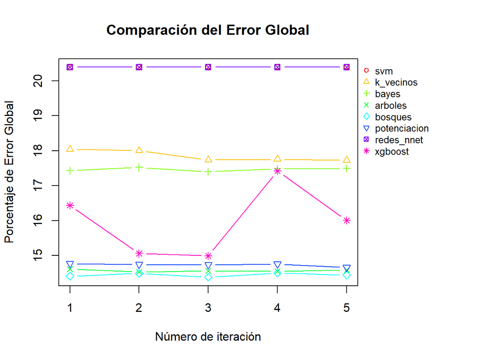

```r
resultados <- data.frame("svm" = deteccion.error.svm,
                         "k_vecinos" = deteccion.error.knn,
                         "bayes" = deteccion.error.bayes,
                         "arboles" = deteccion.error.arbol,
                         "bosques" = deteccion.error.bosque,
                         "potenciacion" = deteccion.error.potenciacion,
                         "redes_nnet" = deteccion.error.red,
                         "xgboost" = deteccion.error.xgboost)

par(oma=c(0, 0, 0, 8)) # Hace espacio para la leyenda
matplot(resultados, type="b", lty = 1, lwd = 1, pch = 1:ncol(resultados),
        main = "Comparación del Error Global",
        xlab = "Número de iteración",
        ylab = "Porcentaje de Error Global",
        col = rainbow(ncol(resultados)))
legend(par('usr')[2], par('usr')[4], legend = colnames(resultados),bty='n', xpd=NA, cex = 0.8,
       pch=1:ncol(resultados), col = rainbow(ncol(resultados))) # La leyenda
```

# Punto C

# Punto D

Encuentre el mejor modelo usando el paquete caret. Para esto compare los metodos SVM, KNN, Arboles, Bosques, Potenciacion, eXtreme Gradient Boosting, Bayes y Regresion Logıstica. Para esto genere muestras de entrenamiento y testing usando la funcion createDataPartition(…), luego genere los modelos usando las funciones trainControl(…) y train(…) con validacion cruzada de 10 grupos y usando como criterio (metrica de calidad) la precision global (Accuracy). Usando la funcion indices.general(…) determine cual es el mejor metodo.

```r
#calculo de indices
indices.general <- function(MC) {
  precision.global <- sum(diag(MC))/sum(MC)
  error.global <- 1 - precision.global
  precision.categoria <- diag(MC)/rowSums(MC)
  res <- list(matriz.confusion = MC, precision.global = precision.global, error.global = error.global,
              precision.categoria = precision.categoria)
  names(res) <- c("Matriz de Confusión", "Precisión Global", "Error Global",
                  "Precisión por categoría")
  return(res)
}


library(caret)
library(traineR)
library(kernlab)
library(fastAdaboost)
library(naivebayes)
datos <- read.csv("Datos_Churn.csv", header=TRUE, sep=",", dec=".")
datos <- datos[, -c(1,4,2,7)]
datos <- na.omit(datos)

datos$TarjetaCredito <- factor(datos$TarjetaCredito, ordered = T)
datos$Activo <- factor(datos$Activo, ordered = T)
datos$DejaBanco <- factor(datos$DejaBanco, ordered = T)
str(datos)
```

```
## 'data.frame':    9845 obs. of  9 variables:
##  $ ScoringCrediticio: int  769 793 746 670 644 787 611 850 445 675 ...
##  $ Genero           : Factor w/ 2 levels "Femenino","Masculino": 2 1 2 1 2 1 1 2 1 1 ...
##  $ Edad             : int  43 63 58 54 30 42 40 40 34 32 ...
##  $ BalanceCuenta    : num  110183 116271 0 95507 44929 ...
##  $ CantidadProductos: int  2 1 3 1 1 2 1 2 2 1 ...
##  $ TarjetaCredito   : Ord.factor w/ 2 levels "0"<"1": 2 2 2 2 2 1 2 1 2 2 ...
##  $ Activo           : Ord.factor w/ 2 levels "0"<"1": 2 2 2 2 2 2 1 2 2 1 ...
##  $ SalarioEstimado  : num  87537 184243 80345 63213 10771 ...
##  $ DejaBanco        : Ord.factor w/ 2 levels "0"<"1": 1 1 2 1 1 1 1 1 1 1 ...
##  - attr(*, "na.action")= 'omit' Named int  45 61 107 201 228 239 308 390 405 531 ...
##   ..- attr(*, "names")= chr  "45" "61" "107" "201" ...
```

```r
summary(datos)
```

```
##  ScoringCrediticio       Genero          Edad       BalanceCuenta
##  Min.   :350.0     Femenino :4474   Min.   :18.00   Min.   :     0
##  1st Qu.:584.0     Masculino:5371   1st Qu.:32.00   1st Qu.:     0
##  Median :652.0                      Median :37.00   Median : 97023
##  Mean   :650.4                      Mean   :38.94   Mean   : 76342
##  3rd Qu.:717.0                      3rd Qu.:44.00   3rd Qu.:127553
##  Max.   :850.0                      Max.   :92.00   Max.   :250898
##  CantidadProductos TarjetaCredito Activo   SalarioEstimado     DejaBanco
##  Min.   :1.000     0:2898         0:4778   Min.   :    11.58   0:7838
##  1st Qu.:1.000     1:6947         1:5067   1st Qu.: 51219.80   1:2007
##  Median :1.000                             Median :100408.31
##  Mean   :1.532                             Mean   :100172.50
##  3rd Qu.:2.000                             3rd Qu.:149418.41
##  Max.   :4.000                             Max.   :199992.48
```

```r
muestra <- createDataPartition(datos$DejaBanco, p = 0.7, list = F)
# 70% para entrenamiento
tabla.datos.vc <- datos[muestra,]
# 30% para prueba
tabla.validacion <- datos[-muestra,]


# SVM Kernel Radial = “svmRadial”
# k-nearest neighbors = “kknn”
# decision tree = “rpart”
# AdaBoost = “adaboost”
# eXtreme Gradient Boosting = “xgbTree”
# Naive Bayes = “naive_bayes”
# Generalized Linear Model = “glm”

# Validación cruzada con 10 folds
control <- trainControl(method = "cv", number = 10)

svmRadial.model <- train(DejaBanco~., data = tabla.datos.vc, method = "svmRadial",trControl = control, metric = "Accuracy", verbose = FALSE)
kknn.model <- train(DejaBanco~., data = tabla.datos.vc, method = "kknn",trControl = control, metric = "Accuracy", verbose = FALSE)
rpart.model <- train(DejaBanco~., data = tabla.datos.vc, method = "rpart",trControl = control, metric = "Accuracy")
#adaboost.model <- train(DejaBanco~., data = tabla.datos.vc, method = "adaboost",trControl = control, metric = "Accuracy", verbose = FALSE)
boosting.model <- train(DejaBanco~., data = tabla.datos.vc, method = "xgbTree",trControl = control, metric = "Accuracy", verbose = FALSE)
naive_bayes.model <- train(DejaBanco~., data = tabla.datos.vc, method = "naive_bayes",trControl = control, metric = "Accuracy", verbose = FALSE)
```

[output not shown]

[output cut: 424 more lines]

[output not shown]

```r
glm.model <- train(DejaBanco~., data = tabla.datos.vc, method = "glm",trControl = control, metric = "Accuracy")


prediccion.svmRadial <- predict(svmRadial.model, tabla.validacion[,-9])
MC <- table(tabla.validacion$DejaBanco,prediccion.svmRadial)
svmRadial.ind <- indices.general(MC)
svmRadial.ind$`Precisión Global`
```

```
## [1] 0.8567558
```

```r
prediccion.kknn <- predict(kknn.model, tabla.validacion[,-9])
MC <- table(tabla.validacion$DejaBanco,prediccion.kknn)
kknn.ind <- indices.general(MC)
kknn.ind$`Precisión Global`
```

```
## [1] 0.8364375
```

```r
prediccion.rpart <- predict(rpart.model, tabla.validacion[,-9])
MC <- table(tabla.validacion$DejaBanco,prediccion.rpart)
rpart.ind <- indices.general(MC)
rpart.ind$`Precisión Global`
```

```
## [1] 0.8320352
```

```r
# prediccion.adaboost <- predict(adaboost.model, tabla.validacion[,-9])
# MC <- table(tabla.validacion$DejaBanco,prediccion.adaboost)
# adaboost.ind <- indices.general(MC)
# adaboost.ind$`Precisión Global`

prediccion.xgbTree <- predict(boosting.model, tabla.validacion[,-9])
MC <- table(tabla.validacion$DejaBanco,prediccion.xgbTree)
boosting.ind <- indices.general(MC)
boosting.ind$`Precisión Global`
```

```
## [1] 0.8621741
```

```r
prediccion.naive_bayes <- predict(naive_bayes.model, tabla.validacion[,-9])
MC <- table(tabla.validacion$DejaBanco,prediccion.naive_bayes)
naive_bayes.ind <- indices.general(MC)
naive_bayes.ind$`Precisión Global`
```

```
## [1] 0.8195056
```

```r
prediccion.glm <- predict(glm.model, tabla.validacion[,-9])
MC <- table(tabla.validacion$DejaBanco,prediccion.glm)
glm.ind <- indices.general(MC)
glm.ind$`Precisión Global`
```

```
## [1] 0.8052828
```

# Respuesta, Según la precision gloabal el mejor método obtenido es el de XG boosting con una precision global del 86%